# **ANALYZING PROMINENT SYMPTOMS OF LUNG CANCER**

## **Fall 2024 Data Science Project**

## By: Fiona McKee, Kevin Nguyen, Isabelle Park, Grace Tang, and Michelle Xie

## Contributions:

- Kevin Nguyen - committed to the Chi-Squared Test and helped with Data Curation and Primary Analysis.
- Fiona McKee - contributed to Dataset Curation and Preprocessing, Data Exploration and Summary Statistics, and wrote in ML Algorithm Training. Also assisted with overall debugging and standardization of formatting.
- Isabelle Park - contributed to the visualization and and wrote in Data Curation and conclusion.
- Grace Tang - choose the data set, wrote the tutorial for Data Curation and Primary Analysis, wrote the introduction, and helped with the machine learning code.
- Michelle Xie - did the whole section for ANOVA Testing, and did the visualization and wrote the description for the Random Forest Classifier. Also troubleshooted and fixed issues that arose from make_classification.

## Introduction

Lung cancer is one of the most life-threatening and prominent diseases worldwide, with numerous factors contributing to its occurrence and development, such as genetics, lifestyle habits and evironment exposures. As with its development, symptoms arrive such as fatigue, chest pain, and anxiety. Understanding such factors through data observation and analysis can help with identifying correlations and relationships. Such action can lead to improved prevention, early detection and treatment strategies.

Our topic is to find the probabiliy a patient has lung cancer given their symptoms. We chose this dataset because we thought it would be interesting to see whether or not we can see how telling certain symptoms are for lung cancer. For example, is high anxiety a larger warning sign for cancer than chest pain? It can also help people create preventative strategies against certain behaviors to decrease the risk of lung cancer. Lastly, it can inform people on possible signs of lung cancer, if they have several of the listed symptoms, it can motivate them to get treatment.

# Data Curation

Data source: https://www.kaggle.com/datasets/akashnath29/lung-cancer-dataset?resource=download

The dataset includes a sample of patients and divides them according to demographics such as age, gender, whether they smoke, etc. It also includes medical history of other illnesses, and finally also classifies the patient by having/not having lung cancer.

# Exploratory Data Analysis

Data preprocessing:

First we import the needed modules for this section.

```python
# Imports
import pandas as pd
import matplotlib.pyplot as plt
import seaborn as sns
from scipy import stats
```

First, we import our dataset, loading it into a dataframe called "lung_cancer_df". We then display the dataframe.

(Note that there are no Yes/No values for a majority of the columns; instead these values are represented numerically. **YES is represented as 2, and NO is represented as 1.**)

```python
## Import Dataset to Dataframe ##
lung_cancer_df = pd.read_csv("dataset.csv")
lung_cancer_df
```

|  | GENDER | AGE | SMOKING | YELLOW_FINGERS | ANXIETY | PEER_PRESSURE | CHRONIC_DISEASE | FATIGUE | ALLERGY | WHEEZING | ALCOHOL_CONSUMING | COUGHING | SHORTNESS_OF_BREATH | SWALLOWING_DIFFICULTY | CHEST_PAIN | LUNG_CANCER |
| --- | --- | --- | --- | --- | --- | --- | --- | --- | --- | --- | --- | --- | --- | --- | --- | --- |
| 0 | M | 65 | 1 | 1 | 1 | 2 | 2 | 1 | 2 | 2 | 2 | 2 | 2 | 2 | 1 | NO |
| 1 | F | 55 | 1 | 2 | 2 | 1 | 1 | 2 | 2 | 2 | 1 | 1 | 1 | 2 | 2 | NO |
| 2 | F | 78 | 2 | 2 | 1 | 1 | 1 | 2 | 1 | 2 | 1 | 1 | 2 | 1 | 1 | YES |
| 3 | M | 60 | 2 | 1 | 1 | 1 | 2 | 1 | 2 | 1 | 1 | 2 | 1 | 2 | 2 | YES |
| 4 | F | 80 | 1 | 1 | 2 | 1 | 1 | 2 | 1 | 2 | 1 | 1 | 1 | 1 | 2 | NO |
| ... | ... | ... | ... | ... | ... | ... | ... | ... | ... | ... | ... | ... | ... | ... | ... | ... |
| 2995 | F | 71 | 2 | 1 | 1 | 2 | 2 | 1 | 1 | 1 | 1 | 2 | 1 | 1 | 2 | NO |
| 2996 | F | 75 | 1 | 2 | 1 | 1 | 1 | 2 | 2 | 2 | 2 | 1 | 1 | 2 | 1 | NO |
| 2997 | F | 62 | 2 | 2 | 2 | 1 | 2 | 2 | 2 | 2 | 1 | 1 | 2 | 2 | 2 | YES |
| 2998 | M | 30 | 1 | 1 | 2 | 2 | 2 | 2 | 2 | 2 | 2 | 1 | 2 | 1 | 2 | YES |
| 2999 | M | 40 | 1 | 2 | 2 | 1 | 1 | 1 | 2 | 2 | 2 | 1 | 1 | 1 | 1 | YES |

3000 rows × 16 columns

Before building our model and experimenting, we have to clean our data first.

```python
# Data preprocessing:
## Info on Data ##
print("Info:")
lung_cancer_df.info()
print("\n*****\n")

## Data Cleaning ##
print(f"Missing data:\n{lung_cancer_df.isnull().sum()}") # Check for missing data (none found so nothing removed)
lung_cancer_df = lung_cancer_df.dropna() # Drop duplicates if there are any

## Normalizing Data ##
# Standardize data representation across the dataframe.
# The unchanged data represents YES using 2 and NO using 1.
# We standardize so that 1 = YES and 0 = NO across the dataset
lung_cancer_df = lung_cancer_df.replace(1, 0)
lung_cancer_df = lung_cancer_df.replace(2, 1)

# Replace the string data in the LUNG_CANCER column with numerical representation as well
lung_cancer_df['LUNG_CANCER'] = lung_cancer_df['LUNG_CANCER'].replace({'YES': 1, 'NO': 0})

# Print modified Dataframe
print('*****')
lung_cancer_df
```

```
Info:
<class 'pandas.core.frame.DataFrame'>
RangeIndex: 3000 entries, 0 to 2999
Data columns (total 16 columns):
 #   Column                 Non-Null Count  Dtype
---  ------                 --------------  -----
 0   GENDER                 3000 non-null   object
 1   AGE                    3000 non-null   int64
 2   SMOKING                3000 non-null   int64
 3   YELLOW_FINGERS         3000 non-null   int64
 4   ANXIETY                3000 non-null   int64
 5   PEER_PRESSURE          3000 non-null   int64
 6   CHRONIC_DISEASE        3000 non-null   int64
 7   FATIGUE                3000 non-null   int64
 8   ALLERGY                3000 non-null   int64
 9   WHEEZING               3000 non-null   int64
 10  ALCOHOL_CONSUMING      3000 non-null   int64
 11  COUGHING               3000 non-null   int64
 12  SHORTNESS_OF_BREATH    3000 non-null   int64
 13  SWALLOWING_DIFFICULTY  3000 non-null   int64
 14  CHEST_PAIN             3000 non-null   int64
 15  LUNG_CANCER            3000 non-null   object
dtypes: int64(14), object(2)
memory usage: 375.1+ KB

*****

Missing data:
GENDER                   0
AGE                      0
SMOKING                  0
YELLOW_FINGERS           0
ANXIETY                  0
PEER_PRESSURE            0
CHRONIC_DISEASE          0
FATIGUE                  0
ALLERGY                  0
WHEEZING                 0
ALCOHOL_CONSUMING        0
COUGHING                 0
SHORTNESS_OF_BREATH      0
SWALLOWING_DIFFICULTY    0
CHEST_PAIN               0
LUNG_CANCER              0
dtype: int64
*****
```

|  | GENDER | AGE | SMOKING | YELLOW_FINGERS | ANXIETY | PEER_PRESSURE | CHRONIC_DISEASE | FATIGUE | ALLERGY | WHEEZING | ALCOHOL_CONSUMING | COUGHING | SHORTNESS_OF_BREATH | SWALLOWING_DIFFICULTY | CHEST_PAIN | LUNG_CANCER |
| --- | --- | --- | --- | --- | --- | --- | --- | --- | --- | --- | --- | --- | --- | --- | --- | --- |
| 0 | M | 65 | 0 | 0 | 0 | 1 | 1 | 0 | 1 | 1 | 1 | 1 | 1 | 1 | 0 | 0 |
| 1 | F | 55 | 0 | 1 | 1 | 0 | 0 | 1 | 1 | 1 | 0 | 0 | 0 | 1 | 1 | 0 |
| 2 | F | 78 | 1 | 1 | 0 | 0 | 0 | 1 | 0 | 1 | 0 | 0 | 1 | 0 | 0 | 1 |
| 3 | M | 60 | 1 | 0 | 0 | 0 | 1 | 0 | 1 | 0 | 0 | 1 | 0 | 1 | 1 | 1 |
| 4 | F | 80 | 0 | 0 | 1 | 0 | 0 | 1 | 0 | 1 | 0 | 0 | 0 | 0 | 1 | 0 |
| ... | ... | ... | ... | ... | ... | ... | ... | ... | ... | ... | ... | ... | ... | ... | ... | ... |
| 2995 | F | 71 | 1 | 0 | 0 | 1 | 1 | 0 | 0 | 0 | 0 | 1 | 0 | 0 | 1 | 0 |
| 2996 | F | 75 | 0 | 1 | 0 | 0 | 0 | 1 | 1 | 1 | 1 | 0 | 0 | 1 | 0 | 0 |
| 2997 | F | 62 | 1 | 1 | 1 | 0 | 1 | 1 | 1 | 1 | 0 | 0 | 1 | 1 | 1 | 1 |
| 2998 | M | 30 | 0 | 0 | 1 | 1 | 1 | 1 | 1 | 1 | 1 | 0 | 1 | 0 | 1 | 1 |
| 2999 | M | 40 | 0 | 1 | 1 | 0 | 0 | 0 | 1 | 1 | 1 | 0 | 0 | 0 | 0 | 1 |

3000 rows × 16 columns

## Basic Data Exploration and Summary Statistics:

Next, we begin with our data exploration, in this section, we chose to use a Chi Squared Test (due to the majority of the data being categorical), a ANOVA Hypothesis test (on the continous data of Age), and a histogram (to explore the possible relationship between two variables).

**Statistical Method 1: Chi Squared Test**

For our Chi Squared Test, we wanted to test if there is a correlation between smoking and contracting lung cancer. First, we develop our hypothesises and our alpha. For our experiment below, assume $\alpha = 0.05$

**H0:** Smoking has no correlation with contracting lung cancer.

**HA:** Smoking has a positive correlation with contracting lung cancer.

Next, we get and print out our p-value from applying the chi-squared test using the `chi2_contingency()` function.

```python
chi_test = pd.crosstab(lung_cancer_df['SMOKING'], lung_cancer_df['LUNG_CANCER'])
chi2_stat, p_val, dof, ex = stats.chi2_contingency(chi_test)
print(f"P-Value: {p_val}")
```

```
P-Value: 0.45790483338496013
```

**Chi Squared Test Explanation and Plot**

Next, we create a plot to help display the relationship between smoking and contracting lung cancer. The best way to show this relationship is through a bar graph.

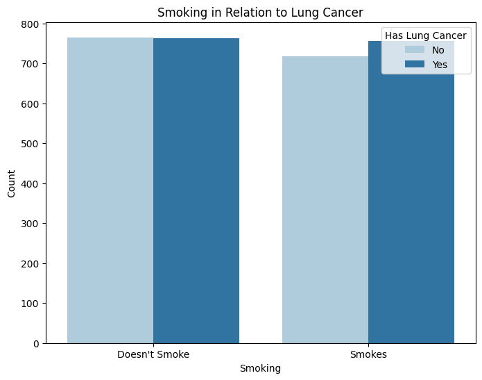

```python
plt.figure(figsize=(8,6))
ax = sns.countplot(x='SMOKING', hue='LUNG_CANCER', data=lung_cancer_df, palette='Paired')
ax.set_xticklabels(['Doesn\'t Smoke', 'Smokes'])

plt.title('Smoking in Relation to Lung Cancer')
plt.xlabel('Smoking')
plt.ylabel('Count')
plt.legend(title='Has Lung Cancer', labels=['No', 'Yes'])
plt.show()
```

The p-value is $0.4$ which is greater than $0.05$, not the mention the graph is relatively uniform. Therefore we cannot reject the null hypothesis within this dataset: "Smoking has no correlation with having lung cancer".

**Statistical Method 2: ANOVA Hypothesis Testing**

Next we'll perform an ANOVA test using different hypothesises. However, our alpha will remain the same at $0.05$.

**H0:** The age of an individual does not have an effect on whether or not they get lung cancer.

**HA:** The age of an individual has an effect on whether or not they get lung cancer.

Categorical binning of ages was used with: https://pandas.pydata.org/docs/reference/api/pandas.cut.html

```python
import pandas as pd
import scipy.stats as stats

print(lung_cancer_df['AGE'].min())
print(lung_cancer_df['AGE'].max())

bins = [30, 40, 50, 60, 70, 80, 90]
labels = ['30 - 40', '40 - 50', '50 - 60', '60 - 70', '70 - 80', '80 - 90']

lung_cancer_df['AGE'] = pd.cut(lung_cancer_df['AGE'], bins = bins, labels = labels, right = False)

thirties_df = lung_cancer_df[(lung_cancer_df['AGE'] == '30 - 40')]
fourties_df = lung_cancer_df[(lung_cancer_df['AGE'] == '40 - 50')]
fifties_df = lung_cancer_df[(lung_cancer_df['AGE'] == '50 - 60')]
sixties_df = lung_cancer_df[(lung_cancer_df['AGE'] == '60 - 70')]
seventies_df = lung_cancer_df[(lung_cancer_df['AGE'] == '70 - 80')]
eighties_df = lung_cancer_df[(lung_cancer_df['AGE'] == '80 - 90')]
```

```
30
80
```

Next, we perform the ANOVA test with our binned dataframes and display the p-value.

```python
# #ANOVA TEST
from scipy.stats import f_oneway
f,p = f_oneway(thirties_df['LUNG_CANCER'], fourties_df['LUNG_CANCER'], fifties_df['LUNG_CANCER'], sixties_df['LUNG_CANCER'], seventies_df['LUNG_CANCER'], eighties_df['LUNG_CANCER'])
print(p)
```

```
0.08276644065559008
```

We then display the graph using `matplotlib` to show the relationship between age and having lung cancer. To keep it simple, we do a bar graph displaying the mean probability of each age group having lung cancer.

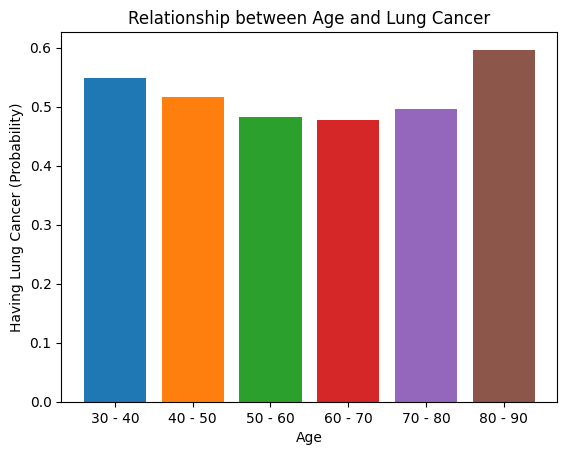

```python
plt.bar(thirties_df['AGE'], thirties_df['LUNG_CANCER'].mean())
plt.bar(fourties_df['AGE'], fourties_df['LUNG_CANCER'].mean())
plt.bar(fifties_df['AGE'], fifties_df['LUNG_CANCER'].mean())
plt.bar(sixties_df['AGE'], sixties_df['LUNG_CANCER'].mean())
plt.bar(seventies_df['AGE'], seventies_df['LUNG_CANCER'].mean())
plt.bar(eighties_df['AGE'], eighties_df['LUNG_CANCER'].mean())

plt.ylabel("Having Lung Cancer (Probability)")
plt.xlabel("Age")
plt.title("Relationship between Age and Lung Cancer")
plt.show()
```

**Statistical Method 3: Histogram**

For our last mode, we will use a combined histogram. These are two separate histograms that both show the relationship between consuming alcohol and having lung cancer, which is then divided based on age. This shows multiple relationships between two factors which may cause lung cancer: age and alcohol consumption.

Like the previous graph, out data will be grouped by age. The first graph is how many consume alcohol while the other consists of people who drink alcohol **and** have lung cancer. We directly plot our two histograms using `sns.histplot`, and set one of the graph's alpha value to 0.5 to make it visible over the other one. Then we label our axises and add in a legend.

More info on `sns`, `histplot` and its features can be found here: https://seaborn.pydata.org/generated/seaborn.histplot.html

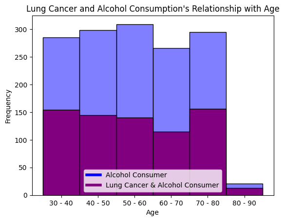

```python
hist1 = sns.histplot(lung_cancer_df[lung_cancer_df['ALCOHOL_CONSUMING'] == 1]['AGE'],color= 'blue', bins=12, alpha=0.5)
hist2 = sns.histplot(lung_cancer_df[(lung_cancer_df['LUNG_CANCER'] == 1) & (lung_cancer_df['ALCOHOL_CONSUMING'] == 1)]['AGE'],color= 'purple', bins=12, alpha=1)
plt.title('Lung Cancer and Alcohol Consumption\'s Relationship with Age')
plt.xlabel('Age')
plt.ylabel('Frequency')
plt.legend(handles=[plt.Line2D([0], [0], color='blue', lw=4, label='Alcohol Consumers'), plt.Line2D([0], [0], color='purple', lw=4, label='Lung Cancer & Alcohol Consumerss')],
           labels=['Alcohol Consumer', 'Lung Cancer & Alcohol Consumer'],
           loc='lower center')
```

**Summary Statistics:**

To finish our exploratory data analysis, we get the summary statistics of our data.

```python
# Summary Statistics
lung_cancer_df.describe()
```

|  | SMOKING | YELLOW_FINGERS | ANXIETY | PEER_PRESSURE | CHRONIC_DISEASE | FATIGUE | ALLERGY | WHEEZING | ALCOHOL_CONSUMING | COUGHING | SHORTNESS_OF_BREATH | SWALLOWING_DIFFICULTY | CHEST_PAIN | LUNG_CANCER |
| --- | --- | --- | --- | --- | --- | --- | --- | --- | --- | --- | --- | --- | --- | --- |
| count | 3000.000000 | 3000.000000 | 3000.000000 | 3000.000000 | 3000.000000 | 3000.000000 | 3000.000000 | 3000.000000 | 3000.000000 | 3000.000000 | 3000.000000 | 3000.000000 | 3000.000000 | 3000.000000 |
| mean | 0.491000 | 0.514000 | 0.494000 | 0.499000 | 0.509667 | 0.489667 | 0.506667 | 0.497333 | 0.491333 | 0.510667 | 0.488000 | 0.489667 | 0.498667 | 0.506000 |
| std | 0.500002 | 0.499887 | 0.500047 | 0.500082 | 0.499990 | 0.499977 | 0.500039 | 0.500076 | 0.500008 | 0.499970 | 0.499939 | 0.499977 | 0.500082 | 0.500047 |
| min | 0.000000 | 0.000000 | 0.000000 | 0.000000 | 0.000000 | 0.000000 | 0.000000 | 0.000000 | 0.000000 | 0.000000 | 0.000000 | 0.000000 | 0.000000 | 0.000000 |
| 25% | 0.000000 | 0.000000 | 0.000000 | 0.000000 | 0.000000 | 0.000000 | 0.000000 | 0.000000 | 0.000000 | 0.000000 | 0.000000 | 0.000000 | 0.000000 | 0.000000 |
| 50% | 0.000000 | 1.000000 | 0.000000 | 0.000000 | 1.000000 | 0.000000 | 1.000000 | 0.000000 | 0.000000 | 1.000000 | 0.000000 | 0.000000 | 0.000000 | 1.000000 |
| 75% | 1.000000 | 1.000000 | 1.000000 | 1.000000 | 1.000000 | 1.000000 | 1.000000 | 1.000000 | 1.000000 | 1.000000 | 1.000000 | 1.000000 | 1.000000 | 1.000000 |
| max | 1.000000 | 1.000000 | 1.000000 | 1.000000 | 1.000000 | 1.000000 | 1.000000 | 1.000000 | 1.000000 | 1.000000 | 1.000000 | 1.000000 | 1.000000 | 1.000000 |

# Primary Analysis

For our primary analysis, we decided to train three models and choose the one with the highest accuracy to use for our analysis. This model ended up being the Random Forest Classifier. It will help us understand more about the relationship that the dataset features have with lung cancer, as well as their degree of influence. As a result, we will be able to extract the most important features for analysis and build a model that can help predict a person's likihood of having lung cancer based on their physical symptoms.

First we import the needed modules for this section.

```python
# Necessary libraries/imports
from sklearn.ensemble import RandomForestClassifier
import matplotlib.pyplot as plt
import matplotlib
import numpy as np
from sklearn.model_selection import train_test_split, cross_val_score, StratifiedKFold
from sklearn.preprocessing import StandardScaler, LabelEncoder
from sklearn.metrics import accuracy_score, classification_report, confusion_matrix, silhouette_score
from sklearn.neighbors import KNeighborsClassifier
from sklearn.datasets import make_classification
from sklearn.linear_model import LogisticRegression
from sklearn.preprocessing import OneHotEncoder
```

Next, we prepare the data for the model. For certain columns, like 'AGE' and 'GENDER', they need to be represented with integers since the models we use cannot transform strings into floats. For this, we use a One-Hot encoding.

[Click here](https://scikit-learn.org/stable/modules/generated/sklearn.preprocessing.OneHotEncoder.html#sklearn.preprocessing.OneHotEncoder) for more info on One-Hot encoding (from sci-kit learn).

```python
# This segment of code will transform the GENDER column, which was formerly
# represented as "M" and "F", into a numeric representation using one-hot encoding.
categorical_columns = ['GENDER']
for col in categorical_columns:
    enc = OneHotEncoder(handle_unknown='ignore')
    lung_cancer_df[col] = enc.fit_transform(lung_cancer_df[[col]]).toarray()

# We do the same thing with age bins
age_columns = ['AGE']
for col in age_columns:
    enc = OneHotEncoder(handle_unknown='ignore')
    lung_cancer_df[col] = enc.fit_transform(lung_cancer_df[[col]]).toarray()
```

After that, we set up our training data and our resulting data. The training data is assigned to `X`, and consists of the dataset with the 'LUNG_CANCER' column dropped. We'll also make another var `y` which is just the 'LUNG_CANCER' column of our dataset, since it is our prediction target.

```python
# Split data with 80/20 ratio and then transform
seed = 42
test_size=0.2

X = lung_cancer_df.drop(['LUNG_CANCER'], axis = 1)
y = lung_cancer_df['LUNG_CANCER']
```

For more info on `train_test_split`: https://scikit-learn.org/stable/modules/generated/sklearn.model_selection.train_test_split.html

```python
X_old = X #for the sake of keeping track of the feature names

X, y = make_classification(n_samples=500, n_features=5, random_state=seed)

X_df = pd.DataFrame(X, columns = X_old.columns[:5].tolist())

X_train, X_test, y_train, y_test = train_test_split(X, y, test_size=test_size, random_state=seed)
```

Then, we normalize our training and testing data sets using a `StandardScaler()`. This ensures that all of the features in the dataset have equal weighting in the model, and also helps the model converge by preventing issues like vanishing or exploding gradients.

For more info on `StandardScaler()`: https://scikit-learn.org/stable/modules/generated/sklearn.preprocessing.StandardScaler.html

```python
scaler = StandardScaler()
X_train_scaled = scaler.fit_transform(X_train)
X_test_scaled = scaler.fit_transform(X_test)
```

We've gotten to the part where we finally build our models. After building our model, we'll fit it with our training data and use it to predict our testing data. The predicted results will be put into a new variable `y_pred`.

## K Neighbors Classifier

We choose a neighbor size of 10. To see how well our model does, we should get the model's accuracy. As an additional information, we should also print out our model's classfication report with accuracy, precision, recall and f1-score.

```python
Kmodel = KNeighborsClassifier(n_neighbors=10)
Kmodel.fit(X_train_scaled, y_train)

y_pred = Kmodel.predict(X_test_scaled)
accuracy = accuracy_score(y_test, y_pred)
print(f"Accuracy: {accuracy * 100:.2f}%")
print(classification_report(y_test, y_pred))
```

```
Accuracy: 94.00%
              precision    recall  f1-score   support

           0       0.94      0.94      0.94        53
           1       0.94      0.94      0.94        47

    accuracy                           0.94       100
   macro avg       0.94      0.94      0.94       100
weighted avg       0.94      0.94      0.94       100
```

The accuracy on this model is 94%, implying that it is fairly accurate. Let's evaluate logistic regression next.

## Logistic Regression

```python
Lrmodel = LogisticRegression()
Lrmodel.fit(X_train_scaled, y_train)

y_pred = Lrmodel.predict(X_test_scaled)
accuracy = accuracy_score(y_test, y_pred)
print(f"Accuracy: {accuracy * 100:.2f}%")
print(classification_report(y_test, y_pred))
```

```
Accuracy: 91.00%
              precision    recall  f1-score   support

           0       0.92      0.91      0.91        53
           1       0.90      0.91      0.91        47

    accuracy                           0.91       100
   macro avg       0.91      0.91      0.91       100
weighted avg       0.91      0.91      0.91       100
```

This model has a lower accuracy of 91%, but it is still fairly accurate.

## Random Forest

To quicken up our runtime and prevent overfitting, we'll add a maximum depth of 3 to our Random Forest Classifier.

```python
# Build and train model
model = RandomForestClassifier(random_state=seed, max_depth=3)

model.fit(X_train_scaled, y_train)
y_pred = model.predict(X_test_scaled)

accuracy = accuracy_score(y_test, y_pred)
np.random.seed(seed)
# Printing this dataset gives us information on which number is designated to
# the respective gender.
# print(lung_cancer_df)
print(f"Accuracy of Random Forest Model: {accuracy:.2f}")
print(classification_report(y_test, y_pred))
```

```
Accuracy of Random Forest Model: 0.95
              precision    recall  f1-score   support

           0       0.96      0.94      0.95        53
           1       0.94      0.96      0.95        47

    accuracy                           0.95       100
   macro avg       0.95      0.95      0.95       100
weighted avg       0.95      0.95      0.95       100
```

It's clear from the accuracy on these three models that Random Forest provides the best results due to its high accuracy. We will use this model moving forwards to analyze our data.

We are interested in determining which of the features in the dataset are the most influential in determining whether an individual has lung cancer. To find out which of these features had the greatest image, we will extract our Random Forest model's four most important features.

For more info on how to extract a model's important features: https://scikit-learn.org/stable/modules/generated/sklearn.tree.DecisionTreeClassifier.html#sklearn.tree.DecisionTreeClassifier.feature_importances_

```python
# Get the most important features of the dataframe
importances = model.feature_importances_

# Creating a DataFrame to display feature importances
feature_importance_df = pd.DataFrame({
    'Feature': X_df.columns,
    'Importance': importances
})


# Displaying feature importances
feature_importance_df = feature_importance_df.sort_values(by='Importance', ascending=False)
feature_importance_df.head(4)
```

|  | Feature | Importance |
| --- | --- | --- |
| 0 | GENDER | 0.460806 |
| 2 | SMOKING | 0.300319 |
| 3 | YELLOW_FINGERS | 0.143195 |
| 4 | ANXIETY | 0.087436 |

# Visualization

This code section will display a visualization of the Random Forest Classifier defined above. To show the graph, we use plot_tree from sklearn (https://scikit-learn.org/1.5/modules/generated/sklearn.tree.plot_tree.html). The first parameter we passed in is the first Random Forest tree. The second parameter is the feature names, and the last parameter is the name of the classes. We limited the max_depth to 3 because that was the max level so that the graph could be depicted clearly.

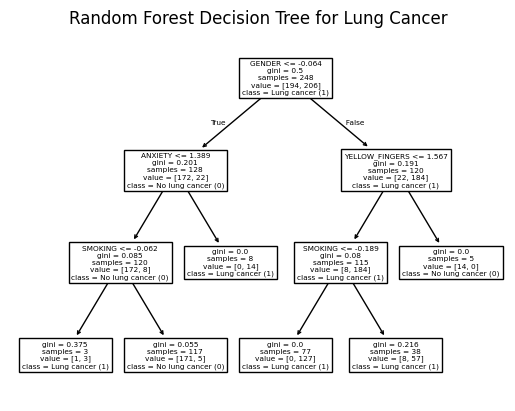

```python
import matplotlib.pyplot as plt
from sklearn import tree
from sklearn.tree import plot_tree

model = model
# features are the different symptoms (Gender...Chest_pain)
# Added title and clearer labeling of lung cancer - Isabelle
tree.plot_tree(model.estimators_[0], feature_names = X_old.columns, class_names = ["No lung cancer (0)", "Lung cancer (1)"])
plt.title("Random Forest Decision Tree for Lung Cancer")
plt.show()
```

# Insights and Conclusions